# Case Study 1 - Doing Data Sceince

Hassan Azhar

October 28, 2016

## Introduction

The purpose of the case study is to evaluate the GDP vs Income provided by Federal Statistics for Education purposes. Data was collected from two different files. Cleane and mergee them to perform some specific analysis as required.

### Part 1: Download the source data, clean, create tidy data for analysis

Getting the data from the server.

```r
FEDSTATS <- read.csv("https://d396qusza40orc.cloudfront.net/getdata%2Fdata%2FEDSTATS_Country.csv", na.strings = c("", "NA"))
GDP <-  read.csv("https://d396qusza40orc.cloudfront.net/getdata%2Fdata%2FGDP.csv", na.strings = c("", "NA"))
```

Loading all the required libraries

```r
library(plyr)
library(ggplot2)
```

#### Cleaning up GDP data

Analyze the columns and data types for the columns

```r
str(GDP)
```

```
## 'data.frame':    330 obs. of  10 variables:
##  $ X                          : Factor w/ 228 levels "ABW","ADO","AFG",..: NA NA NA NA 214 37 101 50 67 71 ...
##  $ Gross.domestic.product.2012: Factor w/ 194 levels ".. Not available.  ",..: NA NA 194 NA 2 103 114 125 136 147 ...
##  $ X.1                        : logi  NA NA NA NA NA NA ...
##  $ X.2                        : Factor w/ 229 levels "  East Asia & Pacific",..: NA NA 66 NA 218 50 107 82 77 217 ...
##  $ X.3                        : Factor w/ 206 levels " 1,008 "," 1,129 ",..: NA 190 206 NA 39 177 142 99 65 62 ...
##  $ X.4                        : Factor w/ 6 levels "a","b","c","d",..: NA NA NA NA NA NA NA NA NA NA ...
##  $ X.5                        : logi  NA NA NA NA NA NA ...
##  $ X.6                        : logi  NA NA NA NA NA NA ...
##  $ X.7                        : logi  NA NA NA NA NA NA ...
##  $ X.8                        : logi  NA NA NA NA NA NA ...
```

```r
GDP$X.3 = as.numeric(gsub(",","",GDP$X.3))
```

Renaming the columns

```r
GDP.NEWNAMES <-rename(GDP, c("X"="CountryCode","Gross.domestic.product.2012" ="Ranking" ,"X.2"="Country","X.3"="GDP","X.4" = "Category"))
```

Removing the bad data

```r
GDP.HEADER <- GDP.NEWNAMES[5:235,]
```

Droping the column with empty data

```r
GDP.DROP <- GDP.HEADER [ -c(3, 7:10) ]
```

Removing countries with no ranking

```r
GDP.DROP <- GDP.DROP[!(is.na(GDP.DROP$Ranking)), ]
GDP.VALUES <- as.numeric(gsub(",", "", GDP.DROP$GDP))
```

Saving tidy data in new data frame

```r
GDP.CLEAN <- GDP.DROP
```

#### Cleaning up Federal Stats data

Analyze the columns and data types for the columns

```r
str(FEDSTATS)
```

```
## 'data.frame':    234 obs. of  31 variables:
##  $ CountryCode                                      : Factor w/ 234 levels "ABW","ADO","AFG",..: 1 2 3 4 5 6 7 8 9 10 ...
##  $ Long.Name                                        : Factor w/ 234 levels "American Samoa",..: 5 104 57 99 108 226 4 109 1 2 ...
##  $ Income.Group                                     : Factor w/ 5 levels "High income: nonOECD",..: 1 1 3 4 5 1 5 4 5 5 ...
##  $ Region                                           : Factor w/ 7 levels "East Asia & Pacific",..: 3 2 6 7 2 4 3 2 1 3 ...
##  $ Lending.category                                 : Factor w/ 3 levels "Blend","IBRD",..: NA NA 3 3 2 NA 2 1 NA 2 ...
##  $ Other.groups                                     : Factor w/ 2 levels "Euro area","HIPC": NA NA 2 NA NA NA NA NA NA NA ...
##  $ Currency.Unit                                    : Factor w/ 154 levels "Afghan afghani",..: 7 48 1 4 2 143 5 6 144 43 ...
##  $ Latest.population.census                         : Factor w/ 27 levels "1970","1979",..: 16 27 2 1 17 21 17 17 16 17 ...
##  $ Latest.household.survey                          : Factor w/ 55 levels "CPS (monthly)",..: NA NA 38 37 39 NA NA 15 NA NA ...
##  $ Special.Notes                                    : Factor w/ 69 levels "A simple multiplier is used to convert the national currencies of EMU members to euros. The following irrevocable euro conversi"| __truncated__,..: NA NA 26 NA NA NA NA NA NA 62 ...
##  $ National.accounts.base.year                      : Factor w/ 43 levels "1954","1973",..: 24 NA 37 27 NA 24 21 NA NA 17 ...
##  $ National.accounts.reference.year                 : int  NA NA NA NA 1996 NA NA 1996 NA NA ...
##  $ System.of.National.Accounts                      : int  NA NA NA NA 1993 NA 1993 1993 NA NA ...
##  $ SNA.price.valuation                              : Factor w/ 2 levels "VAB","VAP": NA NA 1 2 1 1 1 1 NA 1 ...
```

[output cut: 17 more lines]

Analyze the chunks of data

```r
head(FEDSTATS,3)
```

```
##   CountryCode                    Long.Name         Income.Group
## 1         ABW                        Aruba High income: nonOECD
## 2         ADO      Principality of Andorra High income: nonOECD
## 3         AFG Islamic State of Afghanistan           Low income
##                      Region Lending.category Other.groups  Currency.Unit
## 1 Latin America & Caribbean             <NA>         <NA>  Aruban florin
## 2     Europe & Central Asia             <NA>         <NA>           Euro
## 3                South Asia              IDA         HIPC Afghan afghani
##   Latest.population.census Latest.household.survey
## 1                     2000                    <NA>
## 2           Register based                    <NA>
## 3                     1979              MICS, 2003
##                                                                 Special.Notes
## 1                                                                        <NA>
## 2                                                                        <NA>
```

[output cut: 41 more lines]

```r
tail(FEDSTATS,3)
```

```
##     CountryCode                        Long.Name Income.Group
## 232         ZAR Democratic Republic of the Congo   Low income
## 233         ZMB               Republic of Zambia   Low income
## 234         ZWE             Republic of Zimbabwe   Low income
##                 Region Lending.category Other.groups   Currency.Unit
## 232 Sub-Saharan Africa              IDA         HIPC Congolese franc
## 233 Sub-Saharan Africa              IDA         HIPC  Zambian kwacha
## 234 Sub-Saharan Africa            Blend         <NA> Zimbabwe dollar
##     Latest.population.census Latest.household.survey
## 232                     1984                DHS 2007
## 233                     2000               DHS, 2007
## 234                     2002            DHS, 2005/06
##                                                                  Special.Notes
## 232                                                                       <NA>
## 233                                                                       <NA>
```

[output cut: 41 more lines]

Renaming the columns

```r
FEDSTATS.NEWNAMES <-rename(FEDSTATS, c("Long.Name"= "CountryName" , "Income.Group"="IncomeGroup", "Lending.category"="LendingCategoy","Other.groups"="OtherGroups", "Currency.Unit"="Currency" ))
```

We can Keep only the columns we need (if needed)

```r
#FEDSTATS.NEWNAMES <- FEDSTATS.NEWNAMES[c("CountryCode", "CountryName", "IncomeGroup")]
```

Remove all the NA’s from Income Group

```r
FEDSTATS.CLEAN<- FEDSTATS.NEWNAMES[!is.na(FEDSTATS.NEWNAMES$IncomeGroup),]
```

Merge clean Data

```r
data <- merge(FEDSTATS.CLEAN, GDP.CLEAN,by="CountryCode")
```

Number of IDs match

```r
nrow(data)
```

```
## [1] 189
```

### Part 2: Sorting the data and 13th country in the resulting data frame

Sorting data in ascending order

```r
data.ascending <-data[order(data[,34]),]
```

The 13th country in the resulting data frame

```r
data.ascending[13,]
```

```
##    CountryCode         CountryName         IncomeGroup
## 93         KNA St. Kitts and Nevis Upper middle income
##                       Region LendingCategoy OtherGroups
## 93 Latin America & Caribbean           IBRD        <NA>
##                 Currency Latest.population.census Latest.household.survey
## 93 East Caribbean dollar                     2001                    <NA>
##    Special.Notes National.accounts.base.year
## 93          <NA>                        1990
##    National.accounts.reference.year System.of.National.Accounts
## 93                               NA                        1993
##    SNA.price.valuation Alternative.conversion.factor PPP.survey.year
## 93                 VAB                          <NA>              NA
##    Balance.of.Payments.Manual.in.use External.debt.Reporting.status
## 93                              BPM5                    Preliminary
##    System.of.trade Government.Accounting.concept
## 93         General                  Consolidated
##    IMF.data.dissemination.standard
## 93                            GDDS
##    Source.of.most.recent.Income.and.expenditure.data
## 93                                              <NA>
##    Vital.registration.complete Latest.agricultural.census
## 93                        <NA>                       <NA>
##    Latest.industrial.data Latest.trade.data Latest.water.withdrawal.data
## 93                     NA              2007                           NA
##    X2.alpha.code WB.2.code          Table.Name          Short.Name Ranking
## 93            KN        KN St. Kitts and Nevis St. Kitts and Nevis     178
##                Country GDP Category
## 93 St. Kitts and Nevis 767     <NA>
```

```r
AverageGDPRankingOECD <- mean(which(data$IncomeGroup =="High income: OECD"),)
message("Average GDP rankings for the High income: OECD: ", AverageGDPRankingOECD)
```

[output not shown]

```r
AverageGDPRankingnonOECD <- mean(which(data$IncomeGroup =="High income: nonOECD"),)
message("Average GDP rankings for the High income: non OECD: ", AverageGDPRankingnonOECD)
```

```
## Average GDP rankings for the High income: non OECD: 80.0869565217391
```

### Part 4: GDP Plots

Creating a GDP Plot by Income Group

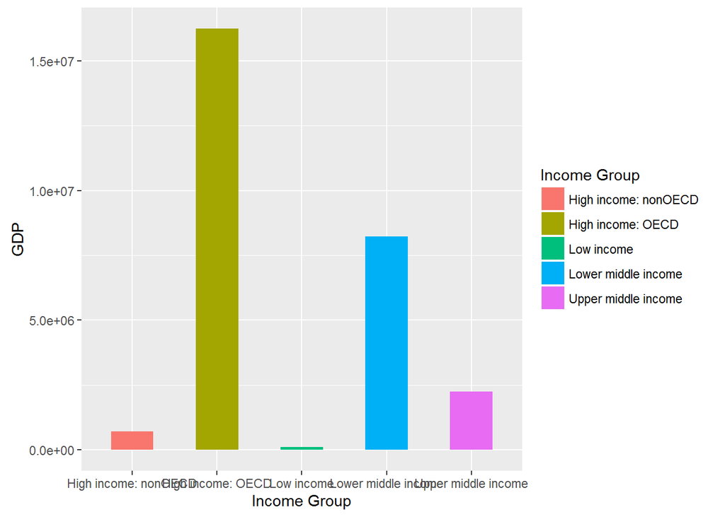

```r
GDPPLOT<-ggplot(data,aes(x=factor(data$IncomeGroup), y=data$GDP, fill=factor(data$IncomeGroup)))+ geom_bar(width=.5,stat="identity", position=position_dodge())+xlab("Income Group")+ylab("GDP")+labs(fill="Income Group")
GDPPLOT
```

### Part 5: GDP ranking into 5 separate quantile groups

Cut the GDP ranking into 5 separate quantile groups

```r
data.ascending$Ranking<- as.numeric(gsub(",","",data.ascending$Ranking))
Quantiles<- cut(data.ascending$Ranking, breaks = 5)
quant <- table(data.ascending$IncomeGroup,Quantiles)
quant
```

```
##                       Quantiles
##                        (0.811,38.8] (38.8,76.6] (76.6,114] (114,152]
##   High income: nonOECD            4           5          8         4
##   High income: OECD              18          10          1         1
##   Low income                      0           1          9        16
##   Lower middle income             5          13         12         8
##   Upper middle income            11           9          8         8
##                       Quantiles
##                        (152,190]
##   High income: nonOECD         2
##   High income: OECD            0
##   Low income                  11
##   Lower middle income         16
##   Upper middle income          9
```

Countries with Lower middle income but among the 38 nations with highest GDP

```r
data.ascending[ data.ascending$IncomeGroup == "Lower middle income" & data.ascending$Ranking <= 38,]
```

```
##     CountryCode                CountryName         IncomeGroup
## 51          EGY     Arab Republic of Egypt Lower middle income
## 165         THA        Kingdom of Thailand Lower middle income
## 77          IDN      Republic of Indonesia Lower middle income
## 78          IND          Republic of India Lower middle income
## 34          CHN People's Republic of China Lower middle income
##                         Region LendingCategoy OtherGroups
## 51  Middle East & North Africa           IBRD        <NA>
## 165        East Asia & Pacific           IBRD        <NA>
## 77         East Asia & Pacific           IBRD        <NA>
## 78                  South Asia          Blend        <NA>
## 34         East Asia & Pacific           IBRD        <NA>
##              Currency Latest.population.census Latest.household.survey
## 51     Egyptian pound                     2006               DHS, 2008
## 165         Thai baht                     2000            MICS 2005/06
```

[output cut: 75 more lines]

### Conclusion

The analysis show that the countries with higher GDP but have a lower middle income group.